# ASSIGMENT_1_SEGURANÇA_PRIVACIDADE

**SECURITY AND PRIVACY**

**Assignment #1** - Performance Benchmarking of Cryptography Mechanisms

Marta Sofia Vieira Longo - 202207985

Sara Catarina Vieira Táboas - 202205101

In this assigment we will measure the time AES, RSA and SHA take to process files of different sizes, using a python implementation of the encryption/decryption and hash mechanisms.

**DESCRIPTION OF THE EXPERIMENTAL SETUP**

- OS: macOS 14.2 23C64 arm64
- Host: Mac15,3
- Kernel: 23.2.0
- Packages: 8 (brew)
- Shell: zsh 5.9
- CPU: Apple M3
- GPU: Apple M3
- Memory: 2376MiB / 16384MiB

**LIBRARIES USED IN THIS PROJECT:**

```python
import os
from os import urandom
from cryptography .hazmat. primitives .ciphers import Cipher , algorithms , modes
from Crypto.Util.Padding import pad, unpad
import timeit
from Crypto.Cipher import AES
from cryptography.hazmat.primitives.asymmetric import rsa
import matplotlib.pyplot as plt
from cryptography.hazmat.primitives.asymmetric import padding
from cryptography.hazmat.primitives import hashes
from cryptography.hazmat.backends import default_backend
import hashlib
```

**A. Generate random text files with the following sizes:**

- For AES (in bytes): 8, 64, 512, 4096, 32768, 262144, 2097152
- For SHA (in bytes): 8, 64, 512, 4096, 32768, 262144, 2097152
- For RSA (in bytes): 2, 4, 8, 16, 32, 64, 128

```python
# Generates random binary text files with size = size
def generate_random_text_file(file_path, size):
    with open(file_path, 'wb') as file:
        file.write(os.urandom(size))

# Uses the generate_random_text_files() defined above to generate 7 text files of different sizes (aes_sizes). Saves those files in an array aes_files
def generate_files_aes():
    aes_sizes = [8, 64, 512, 4096, 32768, 262144, 2097152]
    aes_files = []
    for size in aes_sizes:
        generate_random_text_file(f"aes_{size}.txt", size)
        aes_files.append(f"aes_{size}.txt")
    return aes_files

# Uses the generate_random_text_files() defined above to generate 7 text files of different sizes (sha_sizes). Saves those files in an array sha_files
def generate_files_sha():
    sha_sizes = [8, 64, 512, 4096, 32768, 262144, 2097152]
    sha_files = []
    for size in sha_sizes:
        generate_random_text_file(f"sha_{size}.txt", size)
        sha_files.append(f"sha_{size}.txt")
    return sha_files

# Uses the generate_random_text_files() defined above to generate 7 text files of different sizes (rsa_sizes). Saves those files in an array rsa_files
def generate_files_rsa():
    rsa_sizes = [2, 4, 8, 16, 32, 64, 128]
    rsa_files=[]
    for size in rsa_sizes:
        generate_random_text_file(f"rsa_{size}.txt", size)
        rsa_files.append(f"rsa_{size}.txt")
    return rsa_files
```

**ENCRYPTION AND DECRYPTION USING AES**

**B1. Encrypt and decrypt all these files using AES. Employ a key of 256 bits. Measure the time it takes to encrypt and decrypt each of the files. To do this, you might want to use the python module timeit.**

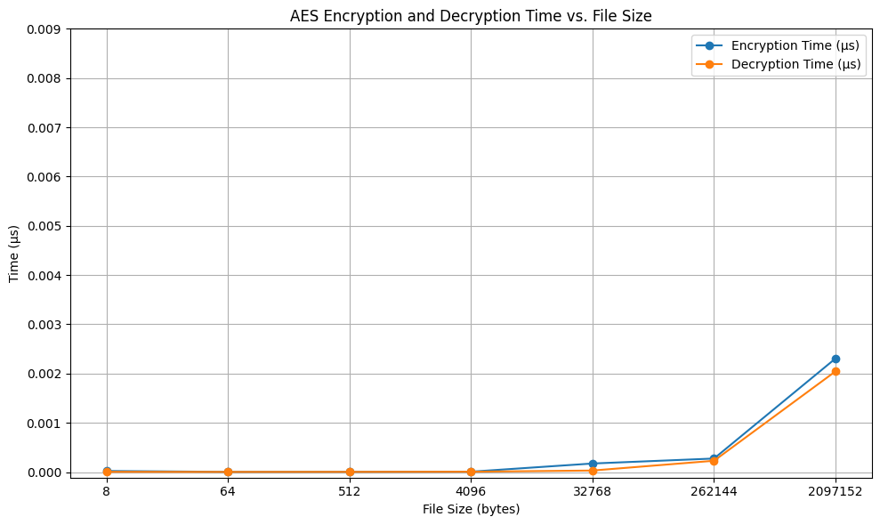

```python
key = os.urandom(32)  # 256-bit key
iv = os.urandom(16)  # 16-byte initialization vector


# Performs AES encryption using the CFB mode and calculates the time the algorithm takes to encrypt a file
def encrypt_aes(file_path, output_file, key, iv):
    backend = default_backend()
    cipher = Cipher(algorithms.AES(key), modes.CFB(iv), backend = backend)
    encryptor = cipher.encryptor()
    with open(file_path, 'rb') as f_in, open (output_file, 'wb') as f_out:
        data = f_in.read()
        start_time = timeit.default_timer()
        encrypted_data = encryptor.update(data) + encryptor.finalize()
        time_encrypt = timeit.default_timer() - start_time
        f_out.write(encrypted_data)
    return time_encrypt

# Performs AES decryption using CFB mode and calculates the time the algorithm takes to decrypt a file
def decrypt_aes(input_file,outout_file, key, iv):
    backend = default_backend()
    cipher = Cipher(algorithms.AES(key), modes.CFB(iv), backend=backend)
    decryptor = cipher.decryptor()
    with open (input_file, 'rb') as f_in, open(outout_file, 'wb') as f_out:
        encrypted_data = f_in.read()
        start_time = timeit.default_timer()
        decrypted_data = decryptor.update(encrypted_data) + decryptor.finalize()
        time_decrypt = timeit.default_timer() - start_time
    return time_decrypt


aes_sizes = [8, 64, 512, 4096, 32768, 262144, 2097152]  # File sizes in bytes
aes_files = generate_files_aes() # Uses the generate_file_aes() function defined in A.
encryption_times_aes = []
decryption_times_aes = []
i = 0 # Control variable to access the sizes in aes_sizes

for file in aes_files: # Repeats the process to all the files in aes_files

    AES_encrypt_time = encrypt_aes(file, f'encrypted_{aes_sizes[i]}.txt', key, iv) # Calculates the encryption time for a file using the encrypt_aes() function
    AES_decrypt_time = decrypt_aes(f'encrypted_{aes_sizes[i]}.txt', f'decrypted_{aes_sizes[i]}.txt', key, iv) # Calculates the encryption time for a file using the encrypt_aes() function

    encryption_times_aes.append(AES_encrypt_time)
    decryption_times_aes.append(AES_decrypt_time)
    i+=1

# Plot of AES encryption / decryption time Vs File size
plt.figure(figsize=(10, 6))
plt.plot(range(1, len(aes_sizes) + 1), encryption_times_aes, marker='o', label='Encryption Time (µs)')
plt.plot(range(1, len(aes_sizes) + 1), decryption_times_aes, marker='o', label='Decryption Time (µs)')

plt.title('AES Encryption and Decryption Time vs. File Size')
plt.xlabel('File Size (bytes)')
plt.ylabel('Time (µs)')
plt.xticks(range(1, len(aes_sizes) + 1), aes_sizes)
plt.yticks([i/1000 for i in range(10)])
plt.grid(True)
plt.legend()
plt.tight_layout()
plt.show()
```

**Observations:**

The plot shows the time spent running the AES algorithm in CFB mode for files with different sizes.

The AES algorithm encrypts the message by dividing the plaintext into blocks and uses the key and the initialization vector to encrypt the first plaintext block, creating the first ciphertext block. Then, it uses that first ciphertext block to encrypt the second plaintext block, and it repeates this process until the end of encryption. To the decryption method (inverse process), it's not necessary to wait for the previous block, because the algorithm receives all of ciphertext blocks at once. This explains the light difference between encryption and decryption times. In addition, as the file size increases, the time AES takes also increases.

**B2. Running an algorithm over the same file multiple times**

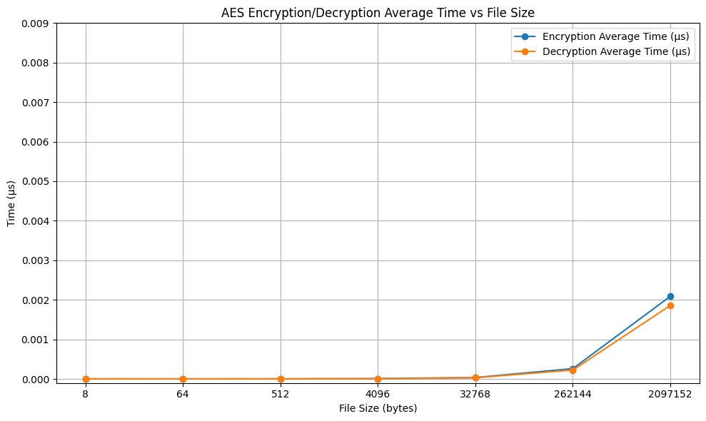

```python
key = os.urandom(32)  # 256-bit key
iv = os.urandom(16)  # 16-byte initialization vector

aes_sizes = [8, 64, 512, 4096, 32768, 262144, 2097152]  # File sizes in bytes
aes_files = generate_files_aes() # Uses the generate_files_aes() function defined in A. to create a list of files

AES_encrypt_average = []
AES_decrypt_average = []
iterations = 200 # Number of times the program will perform the AES encryption/decryption algorithm for each file
i = 0 # Control variable to access the sizes in aes_sizes

for file in aes_files: # Repeats the process for each file of aes_files

    AES_encrypt_sum = 0 # Sum of the encryption times for the 200 repetitions of AES over the same file
    AES_decrypt_sum = 0 # Sum of the decryption times for the 200 repetitions of AES over the same file

    for j in range(iterations):
        AES_encrypt_sum += encrypt_aes(file, f'encrypted_{aes_sizes[i]}.txt', key, iv) # Updates the encryption sum, uses the encrypt_aes() function defined in B1.
        AES_decrypt_sum += decrypt_aes(f'encrypted_{aes_sizes[i]}.txt', f'decrypted_{aes_sizes[i]}.txt', key, iv) # Updates the decryption sum, uses the decrypt_aes() function defined in B1.

    AES_encrypt_avg = AES_encrypt_sum / iterations # Calculates the average time of AES encryption for the same file
    AES_encrypt_average.append(AES_encrypt_avg)
    AES_decrypt_avg = AES_decrypt_sum / iterations # Calculates the average time of AES decryption for the same file
    AES_decrypt_average.append(AES_decrypt_avg)
    i+=1

# Plot of AES encryption / decryption average time Vs File size
plt.figure(figsize=(10, 6))
plt.plot(range(1, len(aes_sizes) + 1), AES_encrypt_average, marker='o', label='Encryption Average Time (µs)')
plt.plot(range(1, len(aes_sizes) + 1), AES_decrypt_average, marker='o', label='Decryption Average Time (µs)')
plt.title('AES Encryption/Decryption Average Time vs File Size')
plt.xlabel('File Size (bytes)')
plt.ylabel('Time (µs)')
plt.xticks(range(1, len(aes_sizes) + 1), aes_sizes)
plt.yticks([i/1000 for i in range(10)])
plt.grid(True)
plt.legend()
plt.tight_layout()
plt.show()
```

**Observations:**

The plot shows the average times spent running the AES algorithm in CFB mode for the same file multiple times.

The average time the AES algortihm uses to encrypt / decrypt multiple times the same file of a specified size does not appear to diverge from the time it takes to encrypt / decrypt just one file - the AES behaviour seems to be the same from the one presented in section **B1**. Therefore, we can conclude that the AES algorithm doesn't change behaviour with the increase of the number of iterations.

**B3. Running an algorithm over multiple randomly generated files of fixed size**

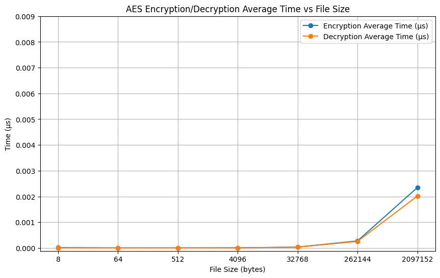

```python
aes_sizes = [8, 64, 512, 4096, 32768, 262144, 2097152]
AES_encryption_multi = []
AES_decryption_multi = []

for size in aes_sizes: # Repeats the process for each size of aes_sizes
    encryption_times = []
    decryption_times = []
    for i in range(5): # Creates 5 files of each size
        in_filename = f'{size}_multi.txt'
        generate_random_text_file(in_filename, size) # Uses the generate_random_text_file() function defined in A.
        AES_encrypt_time = encrypt_aes(in_filename, f'encrypted_{size}.txt', key, iv) # Uses the encrypt_aes() function defined in B1 to calculate the time spent.
        AES_decrypt_time = decrypt_aes(f'encrypted_{size}.txt', f'decrypted_{size}.txt', key, iv) # Uses the decrypt_aes() function defined in B1.

        # Updates the encryption/decryption times list with the times of the 5 different files for each size
        encryption_times.append(AES_encrypt_time)
        decryption_times.append(AES_decrypt_time)

    # Calculate the average encryption/decryption average time for the 5 different files of each size
    encryption_average_time = sum(encryption_times) / len(encryption_times)
    decryption_average_time = sum(decryption_times) / len(decryption_times)

    # Append the averages to the overall list AES_encryption_multi and AES_decryption_multi
    AES_encryption_multi.append(encryption_average_time)
    AES_decryption_multi.append(decryption_average_time)


# Plot of AES encryption / decryption average time VS File size
plt.figure(figsize=(10, 6))
plt.plot(range(1, len(aes_sizes) + 1), AES_encryption_multi, marker='o', label='Encryption Average Time (µs)')
plt.plot(range(1, len(aes_sizes) + 1), AES_decryption_multi, marker='o', label='Decryption Average Time (µs)')
plt.title('AES Encryption/Decryption Average Time vs File Size')
plt.xlabel('File Size (bytes)')
plt.ylabel('Time (µs)')
plt.xticks(range(1, len(aes_sizes) + 1), aes_sizes)
plt.yticks([i/1000 for i in range(10)])
plt.grid(True)
plt.legend()
plt.show()
```

**Observations:**

The plot shows the average time spent running AES algorithm over 5 different files for each size.

The average time the AES algortihm uses to encrypt / decrypt 5 different files of a specified size does not appear to diverge from the time it takes to encrypt / decrypt just one file - the AES behaviour seems to be the same from the one presented in section **B1**. Therefore, we can conclude that the AES algorithm is not affected for the files content.

**ENCRYPTION AND DECRYPTION USING RSA**

**C. Using the python module for RSA encryption and decryption, measure the time of RSA encryption and decryption for the file sizes listed in part A, with a key of size 2048 bits (minimum recommended for RSA).**

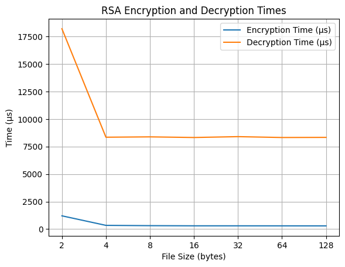

```python
# Function to generate RSA key pair
def generate_rsa_key():
    private_key = rsa.generate_private_key(
        public_exponent=65537,
        key_size=2048,
        backend=default_backend()
    )
    return private_key


# Function to encrypt the plaintext using the public key
def encrypt_rsa(plaintext, public_key):
    ciphertext = public_key.encrypt(
        plaintext,
        padding.OAEP( # The function uses the padding scheme OAEP (Optimal Asymmetric Encryption Padding), usually used in RSA to enhance security and prevent certain cryptographic attacks.
            mgf=padding.MGF1(algorithm=hashes.SHA256()), # Uses for padding the hash algorithm SHA-256
            algorithm=hashes.SHA256(),
            label=None
        )
    )
    return ciphertext


# Function to decrypt the plaintext using the private key
def decrypt_rsa(ciphertext, private_key):
    plaintext = private_key.decrypt(
        ciphertext,
        padding.OAEP(
            mgf=padding.MGF1(algorithm=hashes.SHA256()),
            algorithm=hashes.SHA256(),
            label=None
        )
    )
    return plaintext



rsa_sizes = [2, 4, 8, 16, 32, 64, 128] # File sizes in bytes
encryption_times_rsa = []
decryption_times_rsa = []
rsa_files = generate_files_rsa() # Uses the generate_files_rsa() function defined in A. to create a list of files
private_key = generate_rsa_key() # Generate the private key with generate_rsa_key()
public_key = private_key.public_key()

# Encrypt and decrypt each file, measure the time taken
for file_path, size in zip(rsa_files, rsa_sizes):
    with open(file_path, 'rb') as f:
        file_data = f.read()

    # Measure encryption time
    start_encrypt = timeit.default_timer()
    ciphertext = encrypt_rsa(file_data, public_key)
    end_encrypt = timeit.default_timer()
    encrypt_time = (end_encrypt - start_encrypt) * 1e7 # Converting to nanosseconds
    encryption_times_rsa.append(encrypt_time)

    # Measure decryption time
    start_decrypt = timeit.default_timer()
    decrypted_data = decrypt_rsa(ciphertext, private_key)
    end_decrypt = timeit.default_timer()
    decrypt_time = (end_decrypt - start_decrypt) * 1e7# Converting to nanosseconds
    decryption_times_rsa.append(decrypt_time)

# Combined plot of RSA encryption and decryption times
plt.plot(range(1, len(rsa_sizes) + 1), encryption_times_rsa, label='Encryption Time (µs)')
plt.plot(range(1, len(rsa_sizes) + 1), decryption_times_rsa, label='Decryption Time (µs)')
plt.xlabel('File Size (bytes)')
plt.ylabel('Time (µs)')
plt.xticks(range(1, len(rsa_sizes) + 1), rsa_sizes)
plt.title('RSA Encryption and Decryption Times')
plt.legend()
plt.grid(True)
plt.show()
```

**Observations:**

On the lowest file sizes, we can see a considerable spike because it includes the time the program uses to process the data first. The CPU takes time to process the files and the time used to access the memory is also relevant to explain this results.

In the plot, there is a significant difference between the encryption and the decryption times (explained below). In contrast, it is possible to state that the file size doesn't affect the RSA behaviour - in both processes (encryption and decryption).

**Comparison between RSA encryption and decryption times:**

The RSA algorithm is a assymetric encryption algorithm that relies on exponentiation and modular arithmetic and uses public /private key pair. When encrypting a message, the sender uses the public key of the recipient to compute the ciphertext. When decrypting an RSA encrypted message, the recipient uses their private key to compute the plaintext message.

The time differences between encryption and decryption in the RSA algorithm primarily arise from the differences in exponentiation operations, key sizes, and modular arithmetic computations.

1. **Encryption:** During RSA encryption, the computation involves raising the plaintext message to the power of the public exponent. This operation is relatively efficient, especially if the public exponent is chosen to be a small value like 65537. Therefore, encryption tends to be faster due to the use of smaller exponents and simpler arithmetic operations.
2. **Decryption:** During RSA decryption, the computation involves raising the ciphertext to the power of the private exponent. The private exponent tends to be significantly larger than the public exponent, resulting in more computationally intensive exponentiation operations. Therefore, decryption requires handling larger exponents and more complex arithmetic operations, resulting in longer computation times - explaining the times differences in the plot above.

**ENCRYPTION AND DECRYPTION USING SHA**

**D. Measure the time for SHA-256 hash generation for the file sizes listed in part A.**

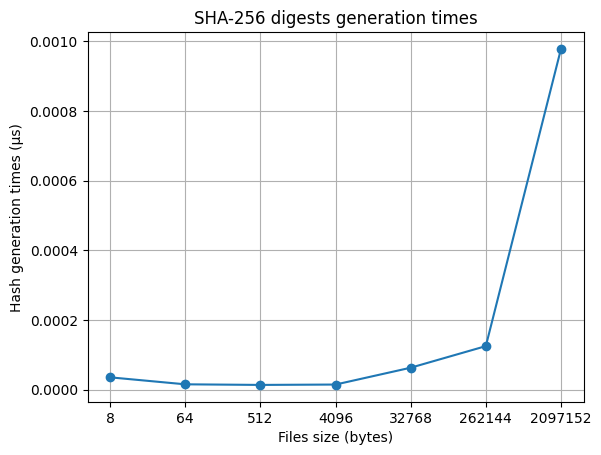

```python
# Function to calculate the SHA-256 hash and convert it to a hexadecimal string
def calculate_sha256_hash(file_path):
    with open(file_path, 'rb') as f:
        data = f.read()
    sha256_hash = hashlib.sha256(data).hexdigest()
    return sha256_hash

# Function to calculate SHA-256 hashes for a list of files and measure the time taken
def calculate_sha256_hash_file_list(file_list):
    sha_hash_times = []
    for file in file_list:
        start_time = timeit.default_timer()
        calculate_sha256_hash(file)
        end_time = timeit.default_timer()
        sha_hash_times.append(end_time - start_time)
    return sha_hash_times

sha_sizes = [8, 64, 512, 4096, 32768, 262144, 2097152] # File sizes in bytes
sha_files = generate_files_sha() # Uses the generate_files_sha() defined in A. to create a list of files
sha_hash_times = calculate_sha256_hash_file_list(sha_files)

plt.plot(range(1, len(sha_sizes) + 1), sha_hash_times, marker='o')
plt.xlabel('Files size (bytes)')
plt.ylabel('Hash generation times (µs)')
plt.xticks(range(1, len(sha_sizes) + 1), sha_sizes)
plt.title('SHA-256 digests generation times')
plt.grid(True)
plt.show()
```

**Observations:**

SHA-256 (Secure Hash Algorithm 256-bit) is a widely used cryptographic hash function that produces a 256-bit (32-byte) hash value from input data. SHA-256 operates by processing input data in blocks of 512 bits and producing a 256-bit hash value as output. It is designed to be computationally secure, meaning it is computationally infeasible to generate two different inputs that produce the same hash value (collision resistance).

The plot shows the hash generation times to files with different sizes. On the first file size, we can see a light spike because it includes the time the program uses to process the data first. The CPU takes time to process the files and the time used to access the memory is also relevant to explain this results.

Through the resulting line, it's possible to state that the hash generation time tends to increase with the increase of file size.

**Comparison between AES encryption and RSA encryption**

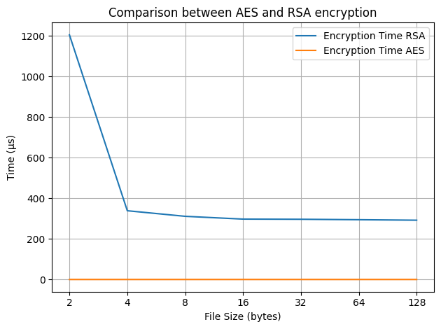

```python
plt.plot(range(1, len(rsa_sizes) + 1), encryption_times_rsa, label='Encryption Time RSA')
plt.plot(range(1, len(aes_sizes) + 1), encryption_times_aes, label='Encryption Time AES')
plt.xlabel('File Size (bytes)')
plt.ylabel('Time (µs)')
plt.xticks(range(1, len(rsa_sizes) + 1),rsa_sizes)
plt.title('Comparison between AES and RSA encryption')
plt.tight_layout()
plt.legend()
plt.grid(True)
plt.show()
```

**Analysis and Conclusions:**

The plot shows AES and RSA encryption times through several files of different sizes. We can state that the RSA algorithm takes more time encrypting a file than AES, due to the differences in their process.

AES encryption involves simple operations, such as substitution, permutations and XOR. As a method of symmetric encryption, it's usually faster than other processes, because it requires less computational power, making it suitable for encrypting large amounts of data.

Another reason why the AES takes less time can be the complexity of RSA when compared to the AES algothimn which in consequence makes the RSA more safer because is very difficult for someone without the private key to acess to the information.

**Comparison between AES encryption and SHA digest generation**

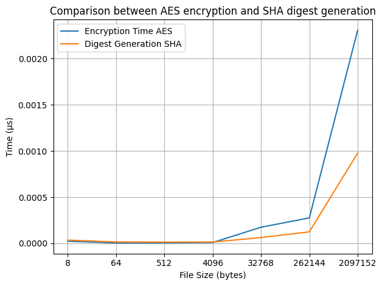

```python
plt.plot(range(1, len(aes_sizes) + 1), encryption_times_aes, label='Encryption Time AES')
plt.plot(range(1, len(sha_sizes) + 1), sha_hash_times, label='Digest Generation SHA')
plt.xlabel('File Size (bytes)')
plt.ylabel('Time (µs)')
plt.xticks(range(1, len(sha_sizes) + 1),sha_sizes)
plt.title('Comparison between AES encryption and SHA digest generation')
plt.tight_layout()
plt.legend()
plt.grid(True)
plt.show()
```

**Analysis and Conclusions:**

The plot shows AES encryption time and SHA digest generation through several files of different sizes. We can state that AES encryption takes more time than SHA-256 digest generation, specially when talking about larger file sizes.

This happens because SHA-256 is a cryptographic hash function that generates a fixed-size hash value from input data. It involves a relatively straightforward set of operations, such as bitwise logical operations, rotations, and modular addition. On the other hand, AES encryption requires multiple rounds of processing for each block of data, with each round involving various operations, such as substitution, permutations and XOR.

**FINAL CONCLUSION**

In this project, we conducted a comprehensive analysis of the performance of symmetric (AES encryption) and asymmetric (RSA encryption and decryption) cryptography algorithms, along with SHA-256 hash generation, using Python's cryptography module. We measured the time taken for cryptographic operations on files of varying sizes and key lengths to understand their efficiency and scalability.